# How grade is affected by students behaviour and environment

## by Wilfred Njeunwi Tagha

## Investigation Overview

> I'm interested in the students activities that can be used for predicting the grade of the student and the environment that can be used for predicting the activities of the student. The activities of interest are absences, outing(goout), Dringking(Dalc and Walc) and studytime while the environment of interest are family relations, Age, Sex and freetime.

## Dataset Overview

> > This data approach student achievement in secondary education of two Portuguese schools. The data attributes include student grades, demographic, social and school related features) and it was collected by using school reports and questionnaires. This dataset has 649 records and 33 features. Most of the variables are categorical. About five columns are numerical such as absences, grades(G1, G2 and G3) and age.

## Grade Distribution

> The grades have a normal distributions with the mode 10.

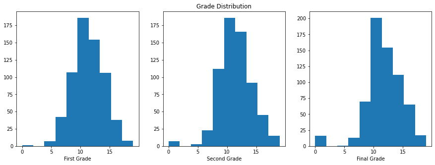

## Gender Distribution

> Females are more than males Females cover 59 percent of the data while males cover 41.

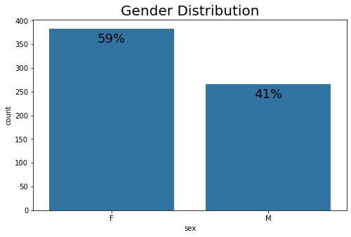

## Effect of studytime on Grade.

> An increase in study time leads to an increase in Grades. However after 10 hours, it seems to be stagnant.

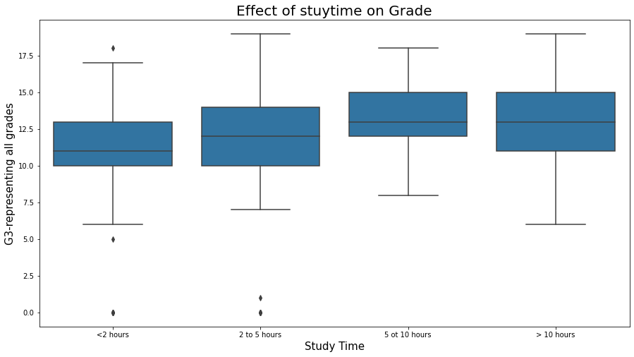

## The effect of study time on grade for each gender

> For females, an increase in study time proves to have an increase effect on grades. For males, an increase in study time only proves to have an increase effect on grades up to 10 hours. After which, the grades drop.

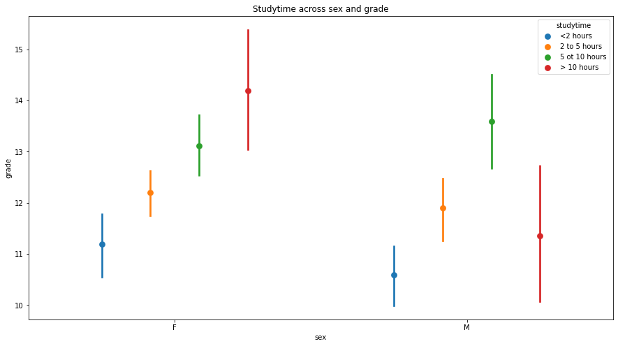